# EEG Language Study

`r`r library(readr) library(dplyr) library(ggplot2) library(ez)

# Behavioral Data Analysis

Begin by loading the **behavioral** data.

`r`r behavioral.data<- read_csv(‘Data/behavioral_data_tidy.csv’)

Adding a percent correct calculation, means and SD

`r`r behavioral.data <- behavioral.data %>% mutate(PercentCorrect = CorrectResponses / 29*100) behavioral.data %>% group_by(Condition) %>% summarize(M= mean(PercentCorrect), SD= sd(PercentCorrect))

| Condition | M | SD |
| --- | --- | --- |
| Anomalous | 94.67085 | 6.044550 |
| Literal | 92.16301 | 6.737989 |
| Metaphorical | 81.50470 | 10.824810 |

Are people more accurate with anamalous sentences than literal sentences?

Are people better at literal than metaphorical?

# EEG Data

Load in EEG Data

`r`r eeg.data <- read_csv(‘Data/voltage_data_tidy.csv’)

Calculate the Grand Averages

`r`r grand.average.data <- eeg.data %>% filter(electrode %in% c(11,62,129)) %>% group_by(electrode, condition, t) %>% summarise(voltage = mean(voltage))

Plot the grand averages

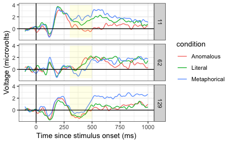

Generating averages for statistical analysis

`r`r eeg.stats.data <- eeg.data %>% filter(electrode %in% c(11,62,129)) %>% filter(t %in% c(300:500)) %>% group_by(electrode, condition, subject) %>% summarize (voltage = mean(voltage)) eeg.stats.data$electrode <- factor(eeg.stats.data$electrode)

Plotted average data

`r`r ggplot(eeg.stats.data, aes(x=electrode, y= voltage, color= condition))+ geom_boxplot()

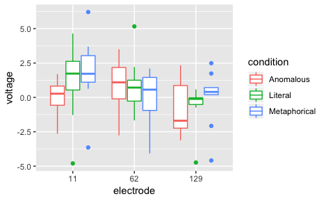

Run a 3x3 ANOVA within subject

`r`r anova.result <- ezANOVA(eeg.stats.data, dv = voltage, within=c(electrode, condition), wid=subject)

```
Converting \subject\ to factor for ANOVA.Converting \condition\ to factor for ANOVA.
```

`r`r anova.result$ANOVA

|  | Effect | DFn | DFd | F | p | p<.05 | ges |
| --- | --- | --- | --- | --- | --- | --- | --- |
| 2 | electrode | 2 | 20 | 3.843077 | 0.03869668 | * | 0.09532930 |
| 3 | condition | 2 | 20 | 1.743741 | 0.20041738 |  | 0.01485052 |
| 4 | electrode:condition | 4 | 40 | 2.552543 | 0.05371728 |  | 0.06323507 |

`r`r eeg.data %>% filter(electrode ==11) %>% ggplot(aes(x=t,y=voltage,color=condition))+ scale_color_brewer(type=,palette=2)+ geom_line()+ facet_wrap(.~subject)

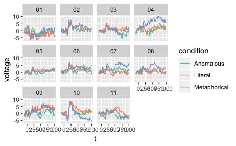